# HCR handout V.1

**Author:** *P.B. Mendes*

## Introduction

This a basic tutorial for modelling, solving and analyzing the epidemiological system proposed in the HCR manuscript. We show to code a system of ordinary differential equations (ODE’s) and how to incorporate arbitrary contact-networks to the model. Also, we show how to evaluate the epidemiological source-sink patterns that emerge from system dynamics.

The document is organized as follows. First we explain some general aspects of the model and show how to write its R code. Second, we show how to define system’s parameters and initial conditions. In this section we also explain how to generate contact-networks with arbitrary structures. Third, we show how to use specific packages and scripts in order to solve the temporal dynamics of the model. Finally, we evaluate the emergence of the source-sink dynamics.

## I) The model

Our model is a multi-host version of the classical susceptible-infected-susceptible ($SIS$) model. The model describes the temporal change in the population density of susceptible and infected classes of $n$ host popuations. “The term ‘density’ is used as a reference for the fact that increasing the number of individuals also increases population crowding” (Mendes & Boeger, 2022).

The dynamics of the model results from the interplay of three subsystems. The first is the ecological subsystem ($ECO$), which described the ecological interactions among host individuals. This subsystem also incorporates intrinsic population rates such born and death rates. In absence of pathogens, model dynamics is driven solely by the ecological subsystem.

The second is the within-host subsystem ($WH$). $WH$ describes the interaction between pathogens and properties of host’s physiology. Because $WH$ is independent of the other subsystems and occurs in a much faster temporal scale, it is assumed to be at their equilibrium. Finally, the third is the epidemiological subsystem ($EPI$), which describes how infection spreads across hosts populations. In terms of subsystems, the model can be written as a set of $n$ pairs of the following equations:
$$\begin{align}
\frac{dS_{i}}{dt}&=ECO_{S_{i}}+EPI_{S_{i}}(WH_{i}) \tag{1a}
\end{align}$$
$$\begin{align}
\frac{dI_{i}}{dt}&=EPI_{I_{i}}(WH_{i})-ECO_{I_{i}} \tag{1b}.
\end{align}$$
System (1) indicates that, while the ecological subsystem is independent of the epidemiological and within-host subsystems, the epidemiology is a function of the within-host dynamics.

For the ecological dynamics, we assume that the population growth of hosts is logistic and that there are no inter-specific interactions among hosts. For the epidemiological system, we assume that pathogen transmission is horizontal (no vertical transmission) and that the transmission rate between each pair of host population is the product of the infectant infectivity $\iota_{i}(z)$, the susceptible susceptibility, $\zeta_{j}$ and the contact rate, $\mathcal{C}_{ij}$ between them, $\beta_{ij}(z)=\iota_{i}(z)\zeta_{j}\mathcal{C}_{ij}$. For the Within-host part, we assume that it is at its equilibrium, as already stated. It is also important to point out that, one of our main assumptions for the model is the virulence-transmission trade-off. This trade-off states that pathogen’s within-host growth rate, $z$, increases both the infectivity of infected individuals and the virulence (disease related death rate of hsots). This trade-off is relevant because it relates to the pathogen position along a fast-slow life-history continuum. Incorporating these assumptions in system (1) yields to the following $SIS$ model:
$$\begin{align}
\frac{dS_{i}}{dt}&=\underbrace{b_{i}N_{i}-S_{i}(d_{i}-l_{i}N_{i})}_{ECO_{S_{i}}}+\underbrace{\gamma_{i}
I_{i}-S_{i}\zeta_{i}\sum_{j=i}^{n}\mathcal{C}_{ji}\underbrace{\iota_{j}(z)}_{WH_{i}}I_{j}}_{EPI_{S_{i}}}
\tag{2a}
\end{align}$$
$$\begin{align}
\frac{dI_{i}}{dt}&=\underbrace{S_{i}\zeta_{i}\sum_{j=i}^{n}\mathcal{C}_{ji}\underbrace{\iota_{j}(z)}_{WH_{i}}I_{j}-I_{i}[\underbrace{\alpha_{j}(z)}_{WH_{i}}+\gamma_{i}]}_{EPI_{I_{i}}}-\underbrace{I_{i}\left(d_{i}+l_{i}N_{i}\right)}_{ECO_{I_{i}}}.
\tag{2b}
\end{align}$$

Then, as a convention, we rearrange the terms to write the same system in a more common form:
$$\begin{align}
\frac{dS_{i}}{dt}&=b_{i}N_{i}+\gamma_{i}
I_{i}-S_{i}\left[d_{i}+l_{i}N_{i}+\zeta_{i}\sum_{j=i}^{n}\mathcal{C}_{ji}\iota_{j}(z)I_{j}\right]
\tag{3a}
\end{align}$$
$$\begin{align}
\frac{dI_{i}}{dt}&=S_{i}\zeta_{i}\sum_{j=i}^{n}\mathcal{C}_{ji}\iota_{j}(z)I_{j}-I_{i}\left[d_{i}+l_{i}N_{i}+\alpha_{i}(z)+\gamma_{i}\right].
\tag{3b}
\end{align}$$
The complete description of the variables and parameters can be found in the attached parameter table or in the main manuscript. The form of functions $\iota_{i}(z)$ and $\alpha_{i}(z)$ will be defined further in this document.

Because the above model may support any number of hosts $n$, it make sense to write these equations in their vector form. This is relevant because it allows us to code only two equations that can be replicated $n$ times in order to reflect the entire community. Here, the notation for vertical vectors is $\vec{x}$. Moreover, we use the operation $\vec{x}\vec{y}$ to indicate that the elements of vector $\vec{x}$ are being multiplied by the corresponding elements of $\vec{y}$. This operation yields to a vector of size identical to the size of $\vec{x}$ and $\vec{y}$. For example, if we have $\vec{x}=(x_{1},...,x_{n})^T$ and $\vec{y}=(y_{1},...,y_{n})^T$, the operation is $\vec{x}\vec{y}=(x_{1}y_{1},...,x_{n}y_{n})^T$. Although not mathematical conventional, this notation reflects the operation performed by the R language. The superscript $T$ means vector transposition. Then, the vector notation for the system is:
$$\begin{align}
\frac{d\vec{S}}{dt}&=\vec{b}\vec{N}+\vec{\gamma}
\vec{I}-\vec{S}\left[\vec{d}+\vec{l}\vec{N}+\vec{\zeta}[\mathsf{C}\cdot(\overrightarrow{\iota}\vec{I})]\right]
\tag{4a}
\end{align}$$
$$\begin{align}
\frac{d\vec{I}}{dt}&=\vec{S}\vec{\zeta}[\mathsf{C}\cdot(\overrightarrow{\iota}\vec{I})]-\vec{I}\left[\vec{d}+\vec{l}\vec{N}+\overrightarrow{\alpha}+\overrightarrow{\gamma}\right]
\tag{4b}.
\end{align}$$
Letter $\mathsf{C}$ stands for a $nXn$ matrix in the WAIFW format (who-acquires-infection-from-whom; Anderson and May 1991). The $\mathsf{C}\cdot(\overrightarrow{\iota}\vec{I})$ operation stands for the dot product (or scalar product) of the WAIFW matrix and the vector $\vec{\iota}\vec{I}$.

The corresponding R code for model (4) is

```r
model = function(t, state, parms){
  with(as.list(c(state,parms)),{
    S=state[1:n]
    I=state[(n+1):(2*n)]
    N=S+I
    dS=N*b+gamma*I-S*(d+l*N+zeta*(C%*%(I*iota)))
    dI=S*zeta*(C%*%(I*iota))-I*(d+l*N+alpha+gamma)
    return(list(c(dS,dI)))
  })
}
```

Then, to solve the above code we must first define the parameters and variables.

## Defining the parameter values

System (3) is composed by several parameters. Some of these parameters are functions of the within-host parameters ($\iota_{i}(z)$ and $\alpha_{i}(z)$). All system parameters can be species-specific and this is why all parameters have the subscript $i$. In this sense, we set parameters to be vertical vectors of size $n$. Thus, we first define the number of different host populations in our system:

```r
n=5
```

Then, to define the parameters we use:

```r
#Parameters # instead of the seq(), you can use c(x1,x2,x3...xn). This allows you to determine any value for any ith parameter
#Ecological
b=matrix(seq(2,2,length=n)) #host born rate # ex: matrix(c(1,1.5,2,1,2.1)) for a n=5
d=matrix(seq(0.2,0.2,length=n)) #host death rate
l=matrix(seq(0.15,0.15,length=n)) #host intraspecific competition
#Epidemiological
zeta=seq(1,1,length=n) #host susceptibility
gamma=matrix(seq(0.2,0.2,length=n)) #host recovery rate
#Within-host
delta=matrix(seq(1,1,length=n)) #lymphocyte mortality
nu=matrix(seq(0.01,0.01,length=n)) #lymphocyte baseline production
mu=matrix(seq(1,1,length=n)) # pathogen killing rate (the rate at which lymphocytes kill pathogens)
c=matrix(seq(5,5,length=n)) #parasite-induced lymhocyte production
u=matrix(seq(1,1,length=n)) # parasite toxicity coefficient
w=matrix(seq(0.25,0.25,length=n)) #lymphocyte side-effect coefficient
a=matrix(seq(2,2,length=n)) #parasite transmission efficiency
z=2.555223 #pathogen within-host per capita growth rate
```

Variability in any parameter can be incorporated by determining a minimum and a maximum value and then replacing the $min$ and $max$ in “seq($min$,$max$,length=$n$)” of the desired parameter. Also, an arbitrary vector of values can be implemented, for any parameter, by replacing the command line for “matrix(c(1,1.5,2,1,2.1))” for parameter values of 1, 1.5,2,1 and 2.1 (where 1 is for parameter value of host $i=1$, 1.5 for $i=2$ and so on).

Now, as we stated, functions for infectivity and virulence have their basis in the within-host system. In the main text we give a more complete explanation for its mechanisms. Following Alizon & van Baalen (2005), the functions for virulence and infectivity are
$$\begin{align}
\alpha_{i}(z)&=u_{i}z\hat{P}_{i}(z)+w_{i}\hat{L}_{i}(z) \tag{5a}
\end{align}$$
$$\begin{align}
\beta_{i}(z)&=a_{i}\hat{P}_{i}(z) \tag{5b}
\end{align}$$
Where $\hat{P}_{i}(z)$ and $\hat{L}_{i}(z)$ are the equilibrium densities of pathogen and lymphocytes, respectively. Here, we use the following set of ODE’s to describe the within-host dynamics:
$$\begin{align}
\frac{dP_{i}}{dt}=P_{i}\left[z-\mu_{i}L_{i}\right], \tag{6a}
\end{align}$$
$$\begin{align}
\frac{dL_{i}}{dt}=\nu_{i}+c_{i}P_{i}-\delta_{i}L_{i}. \tag{6b}
\end{align}$$
Which yields to the following interior equilibrium:
$$\begin{align}
\hat{P}_{i}(z)=\frac{1}{c_{i}}\left(z\frac{\delta_{i}}{\mu_{i}}-\nu_{i}\right),
\tag{7a}
\end{align}$$
$$\begin{align}
\hat{L}_{i}(z)=\frac{z}{\mu_{i}}. \tag{7b}
\end{align}$$

Then, replacing (7) in (5) allows us to write the following code:

```r
#Functions
#Within-host
P=(1/c)*(z*(delta/mu)-nu) #Pathogen load (equation 7a)
L=z/mu #Lymphocyte load (equation 7b)
#Epidemiological
alpha=u*z*P+w*L #virulence (equation 5a)
iota=a*P #invectivity (equation 5b)
```

Now we must define the contact network

### Building the contact network

The R package igraph has a repertoire of tools for visualizing and analyzing networks. Thus, we first install and read the package:

```r
#install.packages(igraph) #comment # if you need to install the igraph package
library(igraph)
```

The network we need is directed (a link $i\longrightarrow j$ is not the same as $j\longrightarrow a$), weighted (links have values that are not necessarily $1$) with nodes representing host populations and links representing the contact rate between them. To build a specific network, first take pen and paper and draw a sketch of your contact network. While doing it, don’t forget to enumerate the nodes with their corresponding indexes $i$. Now, write down (also in pen and paper) who infects whom. For example, if node $1$ infects node $3$, you write “$1\longrightarrow3$”. In the case that node $3$ also infects $1$, discriminate it: “$1\longrightarrow 3$, $3\longrightarrow1$”. To code these links, we create a vector containing the information: from whom, to whom, from whom, to whom… To exemplify, consider the following links: $1\longrightarrow 2$, $1\longrightarrow 3$, $3\longrightarrow 2$, $3\longrightarrow 1$, $5\longrightarrow 5$. In R, we need to generate a vector containing $(1,2,1,3,3,2,3,1,5,5)$. For this, use the code:

```r
links=as.vector(c(1,2,1,3,3,2,3,1,5,5))
```

Now the links are created. Then, we create the corresponding network:

```r
net0=graph_from_adjacency_matrix(as.matrix(as_adjacency_matrix((sample_pa(n=n, power=1, m=0,
directed=F,out.pref=T))%>%add_edges(links))),weighted=TRUE,mode=c("directed"))
V(net0)$Sp=seq(1,n,1) #adding species id to each node
A0=as.matrix(as_adjacency_matrix(net0,attr="weight"))/degree(net0, mode="out",loops=T) #Comment # to incorporate contact dilution
A0[is.nan(A0)] = 0
net=graph_from_adjacency_matrix(A0,weighted=TRUE,mode=c("directed"))
A=as.matrix(as_adjacency_matrix(net, attr="weight"))
```

And use the following to plot the network

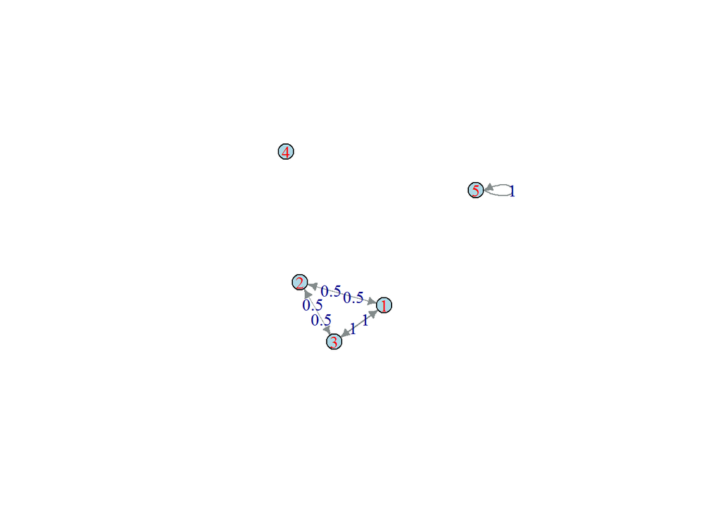

```r
plot(net, vertex.size=17, vertex.label=V(net)$Sp,edge.color="azure4",
     vertex.label.font=1.2,vertex.label.cex=1,vertex.label.degree=pi/2,margin=.5,
     edge.arrow.size=.4,vertex.label.dist=0,edge.width=E(net)$weight,edge.label=E(net)$weight,
     vertex.color="lightblue",
     vertex.label.color="red",layout=layout_with_fr(net),edge.arrow.width=1.5)
```

See if the network have the same structure you have drew in paper. If it does, lets move on. If the networks are not identical, take a second look at the sequence of links of have created.

The adjacency matrix of any network contains the link structure of that network. However, the adjacency matrix $\mathsf{A}$ is in the form who-infects-who. However, the WAIFW matrix $\mathsf{C}$ describes who-aquires-infection-from-whom. Thus, to obtain $\mathsf{C}$ we simply transpose $\mathsf{A}$, $\mathsf{C}=\mathsf{A}^T$. In R:

```r
C=t(A) #the WAIFW matrix
```

### Initial conditions

Here we must define the initial conditions of our model. These are the starting values of the classes densities.

```r
#S=c(0.5,rep(1,(n-1))) #starting with only i=1 infected (change the code with you need infection starting in another i)
#I=c(0.5,rep(0,(n-1))) #starting with only i=1 infected
S=rep(0.5,n)  #all hosts initially infected
I=rep(0.5,n) #all hosts initially infected
```

Clearly, you can always produce specific vectors with “c(S1,S2,S3…Sn)” to insert specific values for the initial conditions. Remember that, since we are talking about population density, a $N=1$ does not means that there is only one individual in the population. Rather, it represents that the ratio between the population size and the abstract space in which the population occurs is $1$.

## Solving the system

Now, to solve the model we use the grind.R script. This script was developed by Rob J de Boer, at the Utrecht University (https://tbb.bio.uu.nl/rdb/grindR.html). The grind.R script has a repertoire of functions for analyzing ordinary differential equations (ODE’s). We use this script because it is adequate to solve ODE’s in their vector form. The grind.R script can be found at https://tbb.bio.uu.nl/rdb/grindR/ . After the script is saved on the folder containing the workplace of your R code, the grind.R script can be loaded by typing:

```r
source("grind.R")
```

```
## grind.R (9-9-2021) was sourced
```

where the name “grind” varies with the name used by the user to save the script. You will notice that grind.R uses a variety of functions of other packages (such as the deSolve package). Thus, take a look at the script and make sure you have all the required packages installed.

The grind.R script comes with a set of color sequence that does not help us visualize our system. The script asks for a “color” object, which must be a sequence of colors. Thus, we first create functions that generate a list of $n$ color names that are successively taken from a determined color gradient. For example, a color gradient that goes from black to white passes through an infinity of gray shades. We choose to represent infected classes as shades of red, and susceptible classes as shades of blue. To do this we run:

```r
colfunc1<-colorRampPalette(c("blue","skyblue"))
#plot(rep(1,10),col=colfunc1(10),pch=19,cex=3) #erase the # to see the color sequence.
colfunc2<-colorRampPalette(c("firebrick","tomato"))
#plot(rep(1,10),col=colfunc2(10),pch=19,cex=3)
colors=c(colfunc1(n),colfunc2(n))
```

Then, the grind.R also needs vectors for initial conditions and parameters:

```r
s=c(S,I)
p=c()
```

The “p=c()” line is an empty vector. There is no need to insert all the parameters inside this vector. The script can identify them once you have created their objects. However, the empty vector is obrigatory for the functioning of the grind.R.

Then use the function “run” from grind.R to solve the temporal dynamics of the differential equations in our model.

```r
OUT=run(tmax=1000,legend = F,table=TRUE,timeplot = F, tstep=0.1)
```

All the temporal dynamics are stored in the “OUT” object. To simplify further analysis, it make sense to extract the values into different objects:

```r
timet=OUT[,1]
S.dy=OUT[,c(2:(n+1))] #Susceptible class dynamics
S.eq=matrix(as.numeric(tail(S.dy)[5,]))
S.eq=ifelse(S.eq<0,0,S.eq) #Susceptible class equilibrium
I.dy=OUT[,c((n+2):(2*n+1))] #Infected class dynamics
I.eq=matrix(as.numeric(tail(I.dy)[5,]))
I.eq=ifelse(I.eq<0,0,I.eq) #Infected class equilibrium
N.dy=S.dy+I.dy #Overall population dynamics
N.eq=S.eq+I.eq #Overall population equilibrium
p.dy=I.dy/rowSums(I.dy) #Prevalence dynamics
p.eq=matrix(as.numeric(tail(p.dy)[5,])) #Prevalence equilibrium
```

Then, to plot the susceptible and infected classes we apply

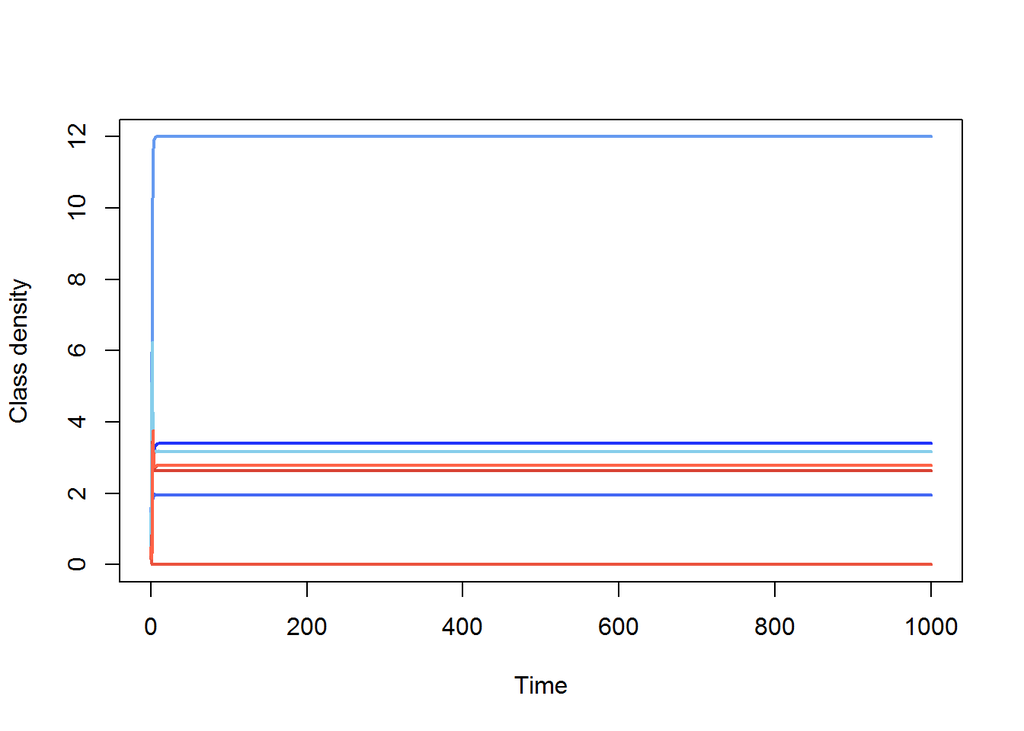

```r
pop=cbind(S.dy,I.dy)
matplot(x=timet,y=pop,type = "l",lwd=2,lty=1,col=c(colfunc1(n),colfunc2(n)),
        xlab="Time",ylab="Class density",frame=T)
```

For the overall population dynamics ($N_{i}=S_{i}+I_{i}$):

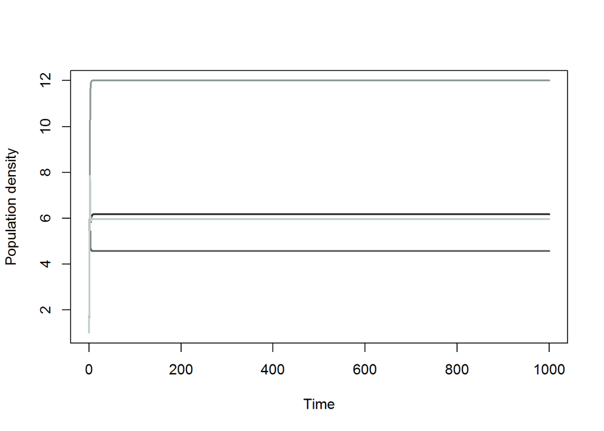

```r
colfunc3<-colorRampPalette(c("black","azure3"))
matplot(x=timet,y=N.dy,type = "l",lwd=2,lty=1,col=c(colfunc3(n)),
        xlab="Time",ylab="Population density",frame=T)
```

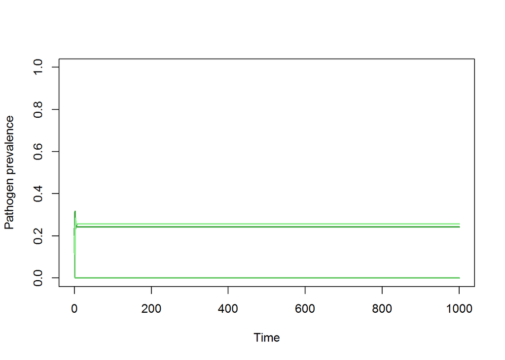

```r
colfunc4<-colorRampPalette(c("darkgreen","lightgreen"))
#plot(rep(1,10),col=colfunc4(10),pch=19,cex=3)
matplot(x=timet,y=p.dy,type = "l",lwd=2,lty=1,col=c(colfunc4(n)),
        xlab="Time",ylab="Pathogen prevalence",frame=T,ylim=c(0,1))
```

## Analysing the emerging source-sink pattern

When the system reaches its interior equilibrium, an epidemiological source-sink pattern emerges from the structure of the contact-network. While sink host populations are those in which pathogen fitness is less then zero, source populations promote a pathogen fitness that is either equal of greater than zero. A fitness equal to zero is considered a source because we are using a measure that is relative and focuses on the differential contribution of individual fitness. In the main text, we show how to derive the following measure for fitness of multi-host pathogens:
$$\begin{align}
F_{i}(z,\vec{\hat{N}})=\iota_{i}(z)\sum_{j=i}^{n}\mathcal{C}_{ij}\zeta_{j}\hat{S}_{j}-\left[d_{i}+l_{i}\hat{N}_{i}+\alpha_{i}(z)+\gamma_{i}\right].
\end{align}$$
The vector version for pathogen fitness is:
$$\begin{align}
\vec{F}=\overrightarrow{\iota}[\mathsf{A}\cdot(\overrightarrow{\zeta}\vec{\hat{S}})]-\left[\vec{d}+\vec{l}\vec{\hat{N}}+\overrightarrow{\alpha}+\overrightarrow{\gamma}\right].
\end{align}$$
And the R countepart for the above equation is:

```r
Fitness=iota*(A%*%(S.eq*zeta))-(d+l*N.eq+alpha+gamma)
```

Note that, for pathogen fitness, we use the contact network adjacency matrix in its original format $\mathsf{A}$, not in the transposed version $\mathsf{A}^T=\mathsf{C}$. The complete explanation for this can be found at the main text of the manuscript.

Now all we have to do is o incorporate the fitness values as an attribute of nodes in the contact network “net”. Thus:

```r
V(net)$Fitness=round(Fitness,8) #the fitness information
V(net)$SourceSink=round(Fitness,8)>=0 #categorical source or sink.
```

Then, to visualize the source-sink pattern we plot the contact network with sink nodes colored in light gray and source nodes colored in dark gray:

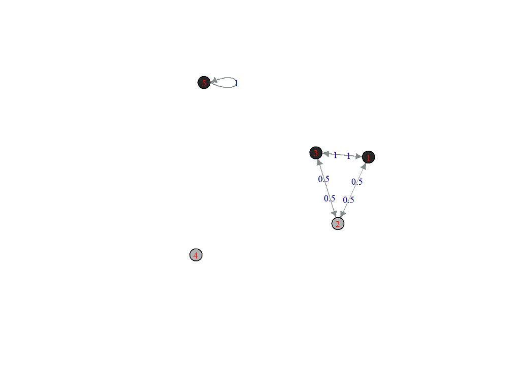

```r
par(mar=c(5,5,2,1)+0,mgp=c(3,1,0),cex=0.75,xpd=F,las=1)
plot(net, vertex.size=15, vertex.label=V(net)$Sp,edge.color="azure4",
     vertex.label.font=1.2,vertex.label.cex=1,vertex.label.degree=pi/2,margin=.5,
     edge.arrow.size=.4,vertex.label.dist=0,edge.width=E(net)$weight,edge.label=E(net)$weight,
     vertex.color=c("gray70","gray15")[1+(V(net)$SourceSink=="TRUE")], #the vertex.color argument
     vertex.label.color="red",layout=layout_with_fr(net),edge.arrow.width=1.5)
```

Remember that the blue numbers in the network are the value of the links.